Holden von Summer DA 101 Dr. Lavin May 17th, 2021 Final Project

What College Major is the Most Stable

**Introduction**: The most common question that any college student is asked is what their major is at school is.Answering that question is easy, but deciding what major to study is a very important decision for college and university students. Their choice of major will determine several of the classes they take and in turn much of their college experience. Choosing a major is like selecting a destination in a GPS for students, its like a guide for them. I choose my major because of a class I took that I enjoyed and that I did well in based off of my test grades and it is a decision that I am happy about. I couldn’t help but wonder what college major is actually the best for students. So I decided to answer that question to the best of my ability by alyzing data. I will be exploring 3 different data sets in my investigation. Interstingly they were very difficult to find online. The first one is titled “tabn324.10,”[^Postsecondary doctor’s - dataset by nces. (2017, January 10). Retrieved March 26, 2021, from https://data.world/nces/postsecondary-doctors] though I call it “degrees_by_study_field1970_2015.csv.” This is a data set that includes how many students across the U.S. graduated with certain degrees by the hundred thousand from 1970 to 2015. I choose it so I could study the popularity of certain study fields. The next data set was titled “degrees-that-pay-back.csv.” [^Journal, T. W. S. (2017, April 29). Where it Pays to Attend College. Kaggle. https://www.kaggle.com/wsj/college-salaries.] This is a survey that conducted a collection of how large the salaries of people in certain fields are. My third data set, and largest one, was titled “college-major/grad-students.csv,” [^Cassleman, B. (2014, September 11). fivethirtyeight/data. GitHub. https://github.com/fivethirtyeight/data/blob/master/college-majors/grad-students.csv.] thought I just titled it “fivethirtyeight_recent_grada_2014.csv” and it is a dataeset that encompasses all kinds of things but I primarily used it to study unemployment of various degrees and jobs that come afterwards. I choose these three data sets because I thought that they would be the most useful in determining what the college major leads to the most stable employment after college.

**Ethical Considerations**: There is a unique aspect to humanity and the world at large called the “Rule of Unintended Consequences.” A simple example is somebody raising the price on deer meat intending to give people more buck for their bang, pun intended, and it causes the local deer population to go extinct. I want to simply answer the question of the most stable college major because I was curious and I hope it does not make someone choose a study field that they hate. My ethical considerations were primarily focused on how my findings could affect the decisions of future students. I do not think that the data sets I choose violate anyone’s private information or expose any secret that previously unannounced. The values for the data in my opinion actually make sense when considered properly. I was concerned about how my research could influence the decisions of other students should this work be published. I think it is important to select a degree of study in life that is a combination of being good at as well as enjoyable. The original question I was going to select was “what college major makes adults the happiest?” I found out that later it was an impossibility to research that without assumptions that data either has a hard time supporting or it is impossible for it to do so. Furthermore, I am completely aware of the fact that choosing a certain major does not guarantee nor bind somebody to a certain list of jobs later in life. Somebody could be an economics major but became a farmer after graduating or through a switch in careers. The same goes for being in school itself because it is possible for students to switch majors in their college careers.

**Data Explanation and Exploration**:

```r
library(tidyverse)
library(dplyr)
salaries <- read_csv('Data/degrees_that_pay_back.csv')
salaries[] <- lapply(salaries, gsub, pattern='\\$', replacement='')
salaries[] <- lapply(salaries, gsub, pattern=',', replacement='')
salaries <- mutate_at(salaries, vars(-undergraduate_major), as.integer)
salaries <- mutate(salaries, undergraduate_major = tolower(undergraduate_major)) %>%
  mutate(undergraduate_major = str_replace_all(undergraduate_major, " ", "_"))
degrees <- read_csv('Data/degrees_by_study_field_1970_2015.csv')
degrees <- filter(degrees, Field_of_study != 'Total')
employment <- read_csv('Data/fivethirtyeight_recent_grads_2014.csv')
employment <- employment %>%
  select(-rank) %>%
  select(-major_code)
```

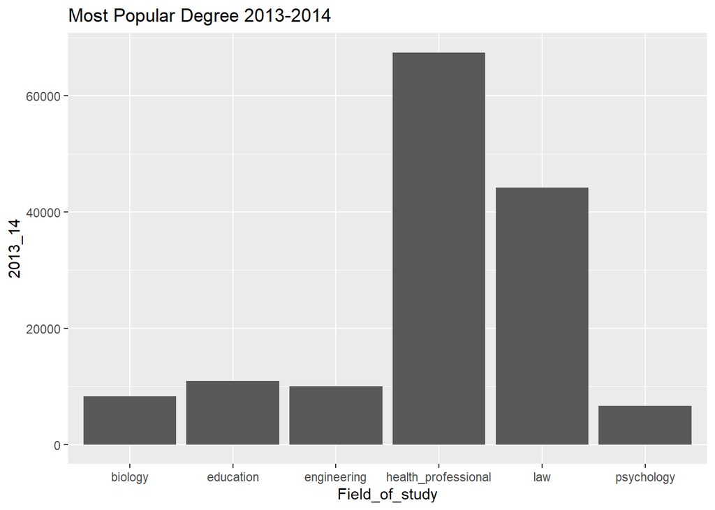

```r
degrees_popular_alltime <- degrees %>% mutate(total=rowSums(select_if(., is.numeric)))
#degrees_popular_alltime <- arrange(degrees_popular_alltime, desc(total))
#ggplot(degrees_popular_alltime[1:5,], aes(x=Field_of_study, y=total)) + geom_bar(stat="identity") + labs(title = 'Most Popular Degree of all time')
degrees_popular_2014_15 <- arrange(degrees, desc(`2013_14`))
ggplot(degrees_popular_2014_15[1:6,], aes(x=Field_of_study, y=`2013_14`)) + geom_bar(stat="identity") + labs(title = 'Most Popular Degree 2013-2014')
```

This is the chart where I determine what is the most popular field of study as of 2013-2014 class across the country. The totals are 1=100,000

Summary of a single column, then do a filter that says everyhting less than is taken out. Maybe use group by

```r
employment_mean_filtered_totals <- employment %>%
  group_by(major_category) %>%
  summarise(field=n(), average = mean(unemployment_rate), comparison = n()*mean(unemployment_rate)) %>%
  arrange(desc(average))
employment_filtered_listed <- employment_mean_filtered_totals[17:12,]
employment_filtered_listed
```

```
## # A tibble: 6 x 4
##   major_category               field average comparison
##   <chr>                        <int>   <dbl>      <dbl>
## 1 industrial_arts                  7  0.0481      0.336
## 2 education                       16  0.0517      0.827
## 3 physical_sciences               11  0.0522      0.574
## 4 agriculure_natural_resources    10  0.0563      0.563
## 5 biology_life_science            14  0.0609      0.853
## 6 engineering                     29  0.0633      1.84
```

From these two data sets I have found three common fields of study that are very popular with students and have a low unemployment rate. Those three fields of study are biology, education, and engineering. There are some difficult things between these data sets because several of them do not have the exact same names for each major field of study. I had to edit some aspect of them by hand in the excel sheets. Furthermore only two data sets are from the 2014 graduating class, the one that is not, the data sheet about salaries is from 2017 while the other two sets of data have information from the 2014 graduating class.

```r
salaries_10th <- select(salaries, undergraduate_major, midcareer_10th_percentile_salary) %>%
  mutate('salary_percentile' = '10')
names(salaries_10th) [2] <- 'midcareer_salaries'
salaries_25th <- select(salaries, undergraduate_major, midcareer_25th_percentile_salary) %>%
  mutate('salary_percentile' = '25')
names(salaries_25th) [2] <- 'midcareer_salaries'
salaries_50th <- select(salaries, undergraduate_major, midcareer_50th_percentile_salary) %>%
  mutate('salary_percentile' = '50')
names(salaries_50th) [2] <- 'midcareer_salaries'
salaries_75th <- select(salaries, undergraduate_major, midcareer_75th_percentile_salary) %>%
  mutate('salary_percentile' = '75')
names(salaries_75th) [2] <- 'midcareer_salaries'
salaries_90th <- select(salaries, undergraduate_major, midcareer_90th_percentile_salary) %>%
  mutate('salary_percentile' = '90')
names(salaries_90th) [2] <- 'midcareer_salaries'
salaries_scatter <- rbind(salaries_10th, salaries_25th, salaries_50th, salaries_75th, salaries_90th)
salaries_scatter <- salaries_scatter[order(salaries_scatter$undergraduate_major),]
salaries_scatter$undergraduate_major <- as.factor(salaries_scatter$undergraduate_major)
```

```r
salaries_scatter_focusMajors1 <- filter(salaries_scatter, grepl('biology|education|aerospace_engineering|chemical_engineering|civil_engineering|computer_engineering|industrial_engineering|mechanical_engineering', undergraduate_major))
shapiro.test(salaries_scatter_focusMajors1$midcareer_salaries)
```

```
##
##  Shapiro-Wilk normality test
##
## data:  salaries_scatter_focusMajors1$midcareer_salaries
## W = 0.96452, p-value = 0.2382
```

```r
#t.test(salaries_scatter_focusMajors1$midcareer_salaries, mu=27,210)
```

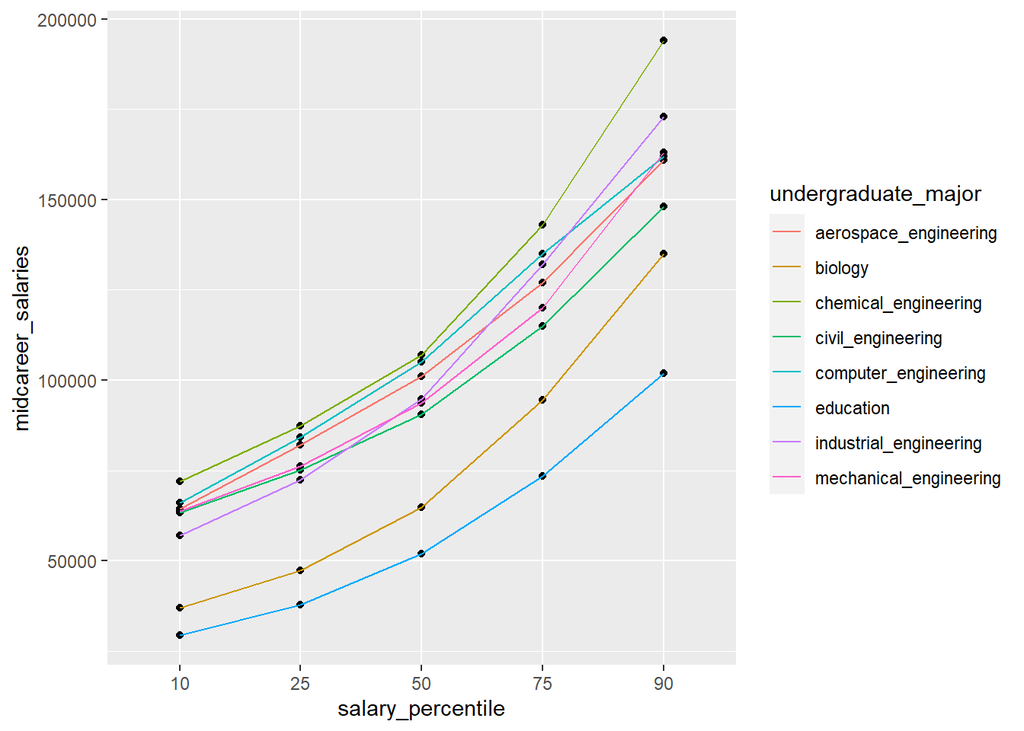

```r
ggplot(salaries_scatter_focusMajors1) + geom_point(aes(x = salary_percentile, y = midcareer_salaries)) + geom_line(aes(x = salary_percentile, y = midcareer_salaries, color = undergraduate_major, group = undergraduate_major))
```

This is a graph that I created to display the salaries of each major study according to the data I collected. The salaries y-axis are not to any scale, the are genuinely 1 to $1, the x-axis however is based off of percentiles. For instance, 25 means that 25% of the surveyed people make that much money or less and the same principle applies to all of the other points. I filtered the information so It would only include the majors that I found prior, those being biology, education, and engineering. Unfortunately as you can see there was not one, but six different fields of engineering in the data set so I decided to include them all. However you can clearly see that both the biology and the education fields of study pay significantly less than most engineering fields by percentile.

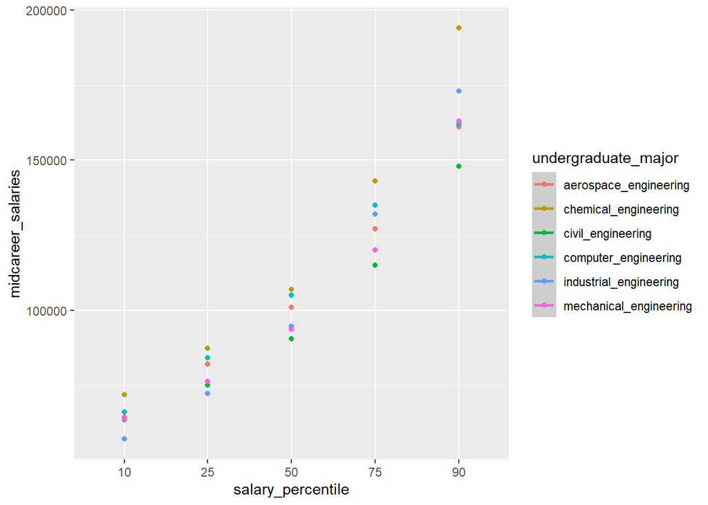

```r
salaries_scatter_focusMajors2 <- filter(salaries_scatter, grepl('aerospace_engineering|chemical_engineering|civil_engineering|computer_engineering|industrial_engineering|mechanical_engineering', undergraduate_major))

ggplot(data=salaries_scatter_focusMajors2, aes(x = salary_percentile, y = midcareer_salaries, color = undergraduate_major)) +
  geom_point() +
  geom_smooth(method ="lm")
```

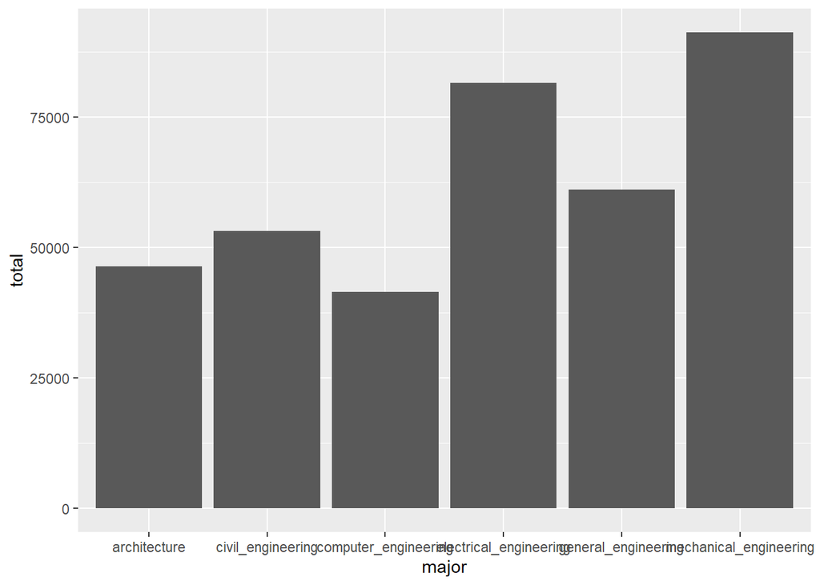

```r
employment_focusMajor1 <- filter(employment, grepl('engineering', major_category))
employment_focusMajor1 <- arrange(employment_focusMajor1, desc(`total`))
ggplot(employment_focusMajor1[1:6,], aes(x=major, y=total)) + geom_col()
```

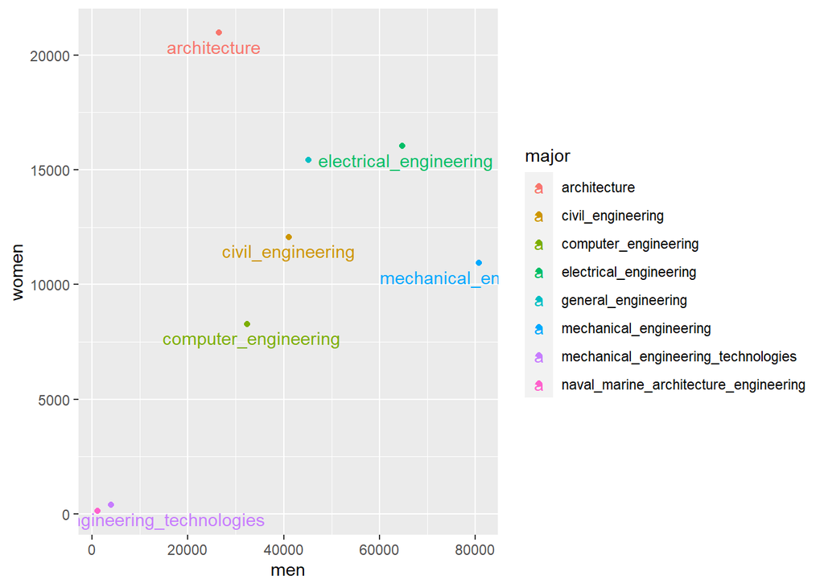

```r
employment_focusMajor2 <- filter(employment_focusMajor1, grepl('architecture|civil_engineering|computer_engineering|electrical_engineering|general_engineering|mechanical_engineering', major))
ggplot(employment_focusMajor2, aes(x=men, y=women, color=major)) + geom_jitter() + geom_text(aes(label = major), check_overlap = TRUE, vjust=1.5)
```

### Project Reflections

I am personally decently satisfied with my work on this project. I have never done a project like this before so I had to think long and hard about how to do it. I choose a question that was important to me and that helped me know what to look for with my research. A rule that I choose that I now regret was selecting a data set for every research purpose I had. I thought that was what I needed to to but in hindsight I recall only needed my ‘fivethirtyeight’ data set because it had details about salaries and about how many people had such a degree. What I think was very effective with my data visualizations was my logic basis of the project. I knew that it would be close to impossible to check every single college major for its attributes so I designed a a road map for narrowing down the best possible choices. I had to modify it a a few times, such as when I got project plan and rubriv criteria, but I think I did a good job with sticking to my plan of narrowing down options. What I wish I did better was that I found another data set that represented the effect that certain jobs have on a person. I am referring to what happens to the social like of workers or to their overall health. Something that is important in life is making sure that your job doesn’t make it such that you are in danger getting hurt. I think that this data could be collected by having people anonymously submit BMI data, or have then undertake a psychological questionnaire to determine their state of mind. This would help me identify jobs that are dangerous and it would help employers monitor the status of their employees.